# Abnormal Statistics

Matthew Talluto

24.02.2022

# One test to rule them all

We’ve learned a great big pile of tests. In reality, they are all the same test:

1. Develop a **null hypothesis** about some **effect** (e.g., there is no difference in means between two groups)
2. Collect some **data**
3. Compute a **test statistic** describing the **effect size**
4. Compute the distribution of the test statistic, *assuming* $H_0$ *is true*
5. Using the distribution, compute how often you would observe a test statistic **as or more extreme** if $H_0$ is true

# Parametric tests have a theoretical distribution

Our tests so far have been (mostly) **parametric**. There is a known theoretical distribution that our test statistic follows.

- The **t-statistic** describes how large a difference between two means is, and follows a t-distribution.
- The **F-statistic** describes a ratio of varainces, and follows an F-distribution.

# Arbitrary test statistics

What do we do if we don’t know the theoretical distribution of our test statistic, or if it doesn’t exist?

# Back to coral reefs

We previously computed parametric confidence intervals for the mean richness in each reef type. However, richness is highly skewed; the mean is a poor estimate of **location** for these data.

# Back to coral reefs

We previously computed parametric confidence intervals for the mean richness in each reef type. However, richness is highly skewed; the mean is a poor estimate of **location** for these data.

### Hypothesis test

$H_0$: The difference in medians is zero

**Rephrased**: Group doesn’t matter, any difference in median we observe is due to chance.

# Back to coral reefs

$H_0$: The difference in medians is zero

We can test this hypothesis by **permutation**.

- If we randomly assign the groups, we simulate a world where $H_0$ is true.

```r
# randomly shuffle the order of the grouping variable
type_shuffle = sample(fish$type)
head(cbind(fish, type_shuffle), 12)
```

```
##    richness     type type_shuffle
## 1        81 tropical     tropical
## 2        95 tropical  subtropical
## 3       103 tropical  subtropical
## 4        91 tropical     tropical
## 5       101 tropical     tropical
## 6        96 tropical     tropical
## 7        51 tropical  subtropical
## 8        95 tropical  subtropical
## 9       105 tropical     tropical
## 10      103 tropical     tropical
## 11       97 tropical     tropical
## 12      104 tropical     tropical
```

# Permutation test for coral reefs

$H_0$: The difference in medians is zero

1. Randomly assign the groups
2. Compute the test statistic (difference between medians)

```r
compute_diff = function(richness, groups) {
    med_trop = median(richness[groups == "tropical"])
    med_sub = median(richness[groups == "subtropical"])
    return(med_trop - med_sub)
}
compute_diff(fish$richness, type_shuffle)
```

```
## [1] -78.5
```

```r
# compare to non-shuffled
compute_diff(fish$richness, fish$type)
```

```
## [1] 267.5
```

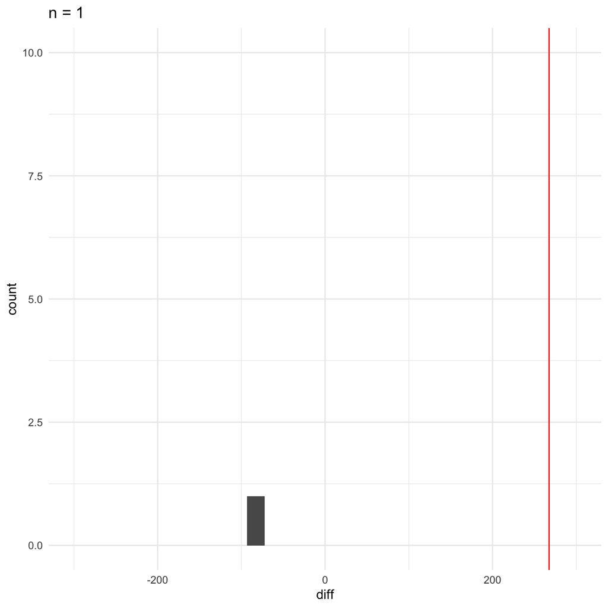

# Permutation test for coral reefs

$H_0$: The difference in medians is zero

1. Randomly assign the groups
2. Compute the test statistic (difference between medians)
3. Repeat many times

```r
n = 100 # number of repeats
# make an empty numeric vector to store the results
results = numeric(n)

# repeat n times
for(i in 1:n) {
    # shuffle the groups
    type_shuffle = sample(fish$type)
    # compute and save the test statistic
    results[i] = compute_diff(fish$richness, type_shuffle)
}
```

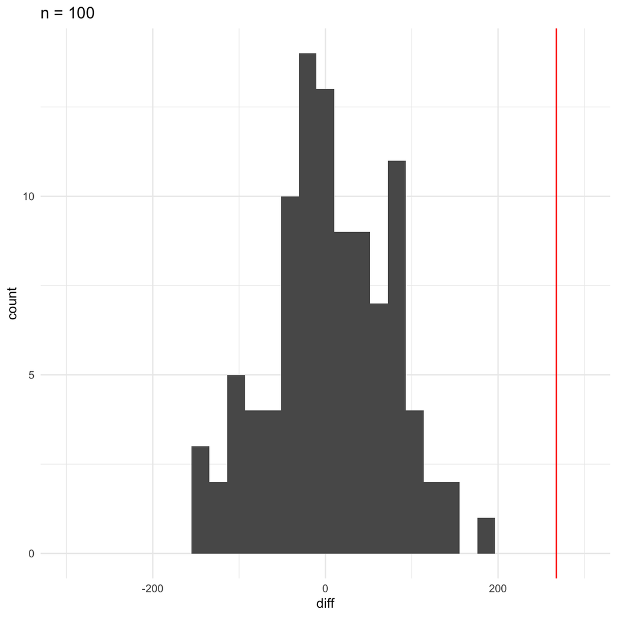

# Permutation test for coral reefs

$H_0$: The difference in medians is zero

1. Randomly assign the groups
2. Compute the test statistic (difference between medians)
3. Repeat **many** times

```r
n = 1e6 # number of repeats
# make an empty numeric vector to store the results
results = numeric(n)

# repeat n times
for(i in 1:n) {
    # shuffle the groups
    type_shuffle = sample(fish$type)
    # compute and save the test statistic
    results[i] = compute_diff(fish$richness, type_shuffle)
}
```

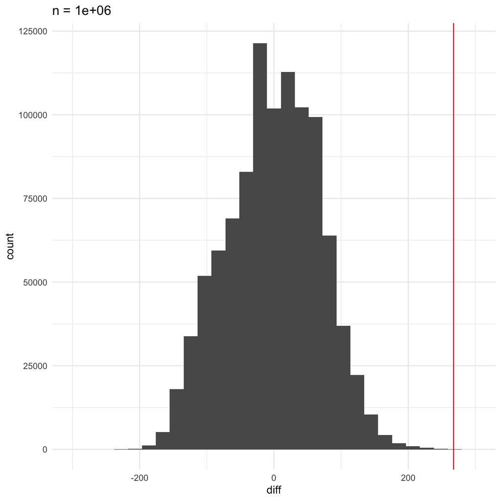

# Permutation test for coral reefs

$H_0$: The difference in medians is zero

1. Randomly assign the groups
2. Compute the test statistic (difference between medians)
3. Repeat **many** times
4. Compute how often a you get a result **as or more extreme** than observed in the sample

```r
# the real difference observed in my sample
(samp_diff = compute_diff(fish$richness, fish$type))
```

```
## [1] 267.5
```

```r
# the frequency: how many times were my sims as or more extreme?
(freq = sum(abs(results) >= samp_diff))
```

```
## [1] 14
```

```r
freq / length(results) ## the p-value
```

```
## [1] 1.4e-05
```

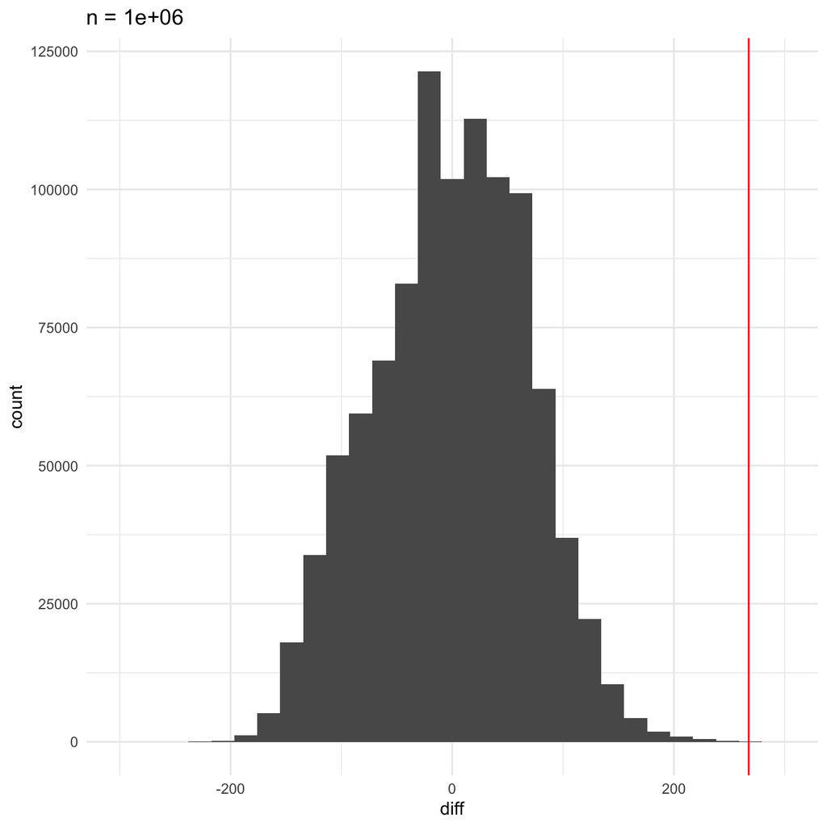

# Parameter estimation

- My permutation test lets me conclude that the medians of the two reef types are not the same. But what if I instead want a confidence interval for the medians?

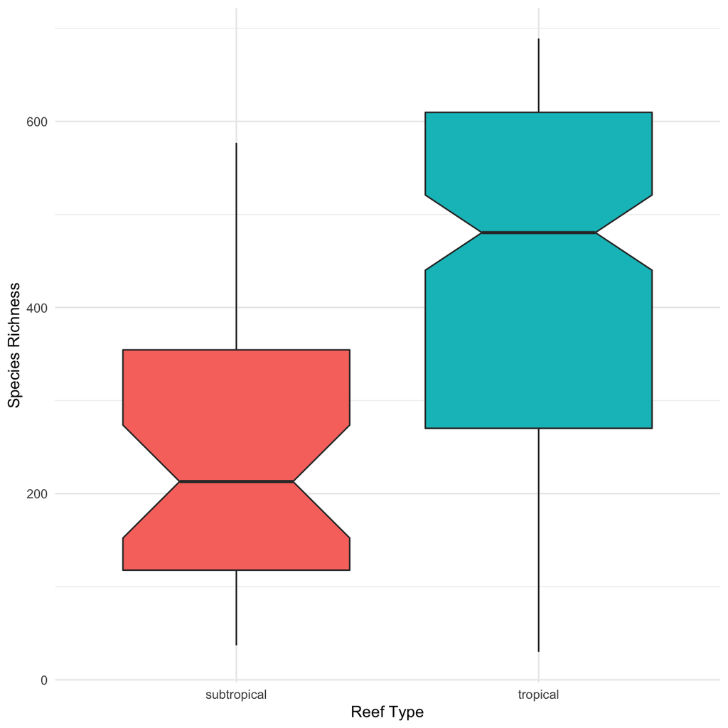

# Nonparametric bootstrap

- My permutation test lets me conclude that the medians of the two reef types are not the same. But what if I instead want a confidence interval for the medians?
- A **nonparametric bootstrap** lets you estimate a confidence interval for (nearly) any statistic.

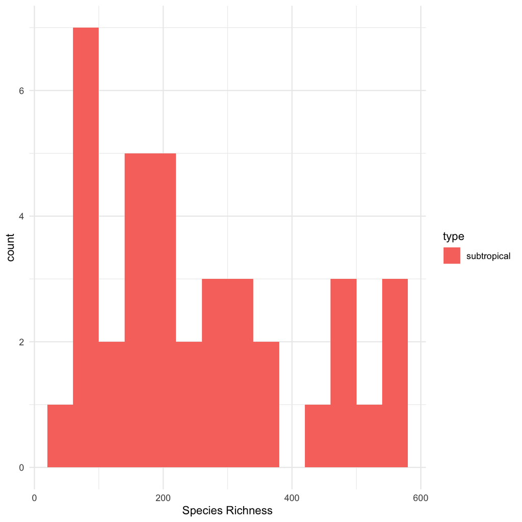

# Nonparametric bootstrap

- My permutation test lets me conclude that the medians of the two reef types are not the same. But what if I instead want a confidence interval for the medians?
- A **nonparametric bootstrap** lets you estimate a confidence interval for (nearly) any statistic.
  - Basic idea: our sample is the best information we have about the population.
  - The population probably resembles the sample, just much larger

# Nonparametric bootstrap

- My permutation test lets me conclude that the medians of the two reef types are not the same. But what if I instead want a confidence interval for the medians?
- A **nonparametric bootstrap** lets you estimate a confidence interval for (nearly) any statistic.
  - Basic idea: our sample is the best information we have about the population.
  - The population probably resembles the sample, just much larger
  - We can understand the distribution of our statistic by sampling repeatedly from the population.

```r
for(i in 1:1000)
    median(sample(population$richness))
```

# Nonparametric bootstrap

- My permutation test lets me conclude that the medians of the two reef types are not the same. But what if I instead want a confidence interval for the medians?
- A **nonparametric bootstrap** lets you estimate a confidence interval for (nearly) any statistic.
  - Basic idea: our sample is the best information we have about the population.
  - The population probably resembles the sample, just much larger
  - We can understand the distribution of our statistic by sampling repeatedly from the population.
  - We don’t have access to the population, so we just use the best information we have: the sample.

```r
fish_subtropical = subset(fish, type == "subtropical")

# generates a new "simulated" sample
new_sample = sample(fish_subtropical$richness,
                    nrow(fish_subtropical),
                    replace = TRUE)

c(median(new_sample),
    median(fish_subtropical$richness))
```

```
## [1] 185 213
```

# Nonparametric bootstrap

- My permutation test lets me conclude that the medians of the two reef types are not the same. But what if I instead want a confidence interval for the medians?
- A **nonparametric bootstrap** lets you estimate a confidence interval for (nearly) any statistic.
  - Basic idea: our sample is the best information we have about the population.
  - The population probably resembles the sample, just much larger
  - We can understand the distribution of our statistic by sampling repeatedly from the population.
  - We don’t have access to the population, so we just use the best information we have: the sample.
  - Do this lots of times

```r
n = 10000
# one column for tropical medians, one for subtropical
# initially fill with NA values, but warn R that the matrix will take numbers
bs_medians = matrix(as.numeric(NA), ncol = 2, nrow=n)
colnames(bs_medians) = c("subtropical", "tropical")

# split the data frame, for clarity
fish_st = subset(fish, type == "subtropical")
fish_t = subset(fish, type == "tropical")

for(i in 1:n) {
    bs_medians[i, 1] = median(sample(fish_st$richness,
            nrow(fish_st), replace = TRUE))
    bs_medians[i, 2] = median(sample(fish_t$richness,
            nrow(fish_t), replace = TRUE))
}
```

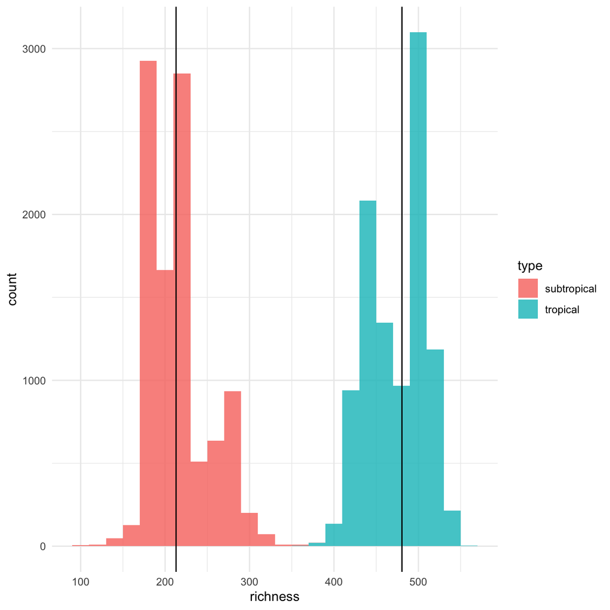

# Nonparametric bootstrap

- My permutation test lets me conclude that the medians of the two reef types are not the same. But what if I instead want a confidence interval for the medians?
- A **nonparametric bootstrap** lets you estimate a confidence interval for (nearly) any statistic.
  - Basic idea: our sample is the best information we have about the population.
  - The population probably resembles the sample, just much larger
  - We can understand the distribution of our statistic by sampling repeatedly from the population.
  - We don’t have access to the population, so we just use the best information we have: the sample.
  - Do this lots of times
  - Get empirical quantiles for the confidence intervals

```r
    (cis = apply(bs_medians, 2, quantile, c(0.025, 0.975)))
```

```
##       subtropical tropical
## 2.5%        172.5    413.5
## 97.5%       293.5    529.5
```

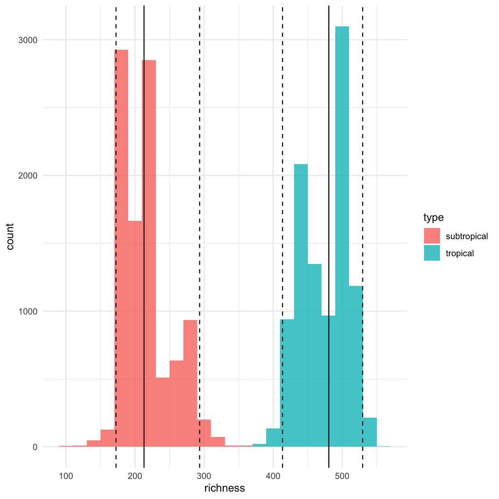

# Special case: linear models

- We have mentioned that the linear model assumes a normal distribution of the residuals.
- Non-parametric linear models are quite weak.
- Transformations of the y-variable change hypotheses and can introduce bias.
- Can we assume other distributions?
- Can we change the linear assumption?

# Generalised linear models

- What about the case of count data?
- Count data often result from a **Poisson process** and follow a Poisson distribution
- Poisson processes are **exponential** with a rate of occurrence $\lambda$
- **Examples**
  - Clicks of a Geiger counter
  - Animals born when birth rate (within subgroups) is constant
  - Number of individuals/species in a study plot

$$\begin{aligned}
\lambda & = e^{\beta_0 + \beta_1x_1 \ldots \beta_k x_k} \\
& = e^{\mathbf{B}\mathbf{X}} \\
y & \sim \mathcal{P}(\lambda)
\end{aligned}$$

# Example: Poisson

**Hypothesis**: The rate of technological development $\lambda_{\mathrm{tools}}$ among indigenous populations increases with log-population size and with the degree of contact with other civilisations.

```r
head(tools)
```

```
##      culture tool_types population contact age_ky
## 1   Malekula         13       1100      lo    0.5
## 2    Tikopia         22       1500      lo    0.7
## 3 Santa Cruz         24       3600      lo    3.3
## 4        Yap         43       4791      hi    1.0
## 5   Lau Fiji         33       7400      hi    3.5
## 6  Trobriand         19       8000      hi    3.3
```

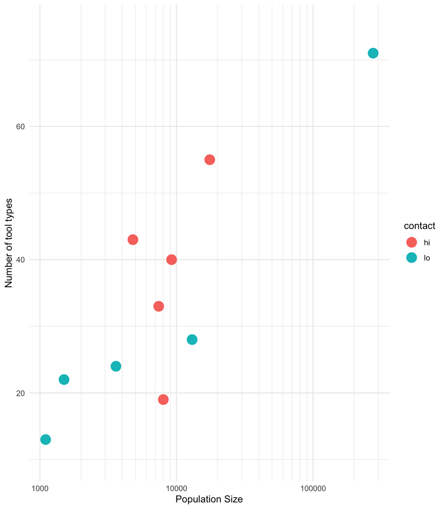

```r
pl_tools
```

# Example: Poisson

**Hypothesis**: The rate of technological development $\lambda_{\mathrm{tools}}$ among indigenous populations increases with log-population size and with the degree of contact with other civilisations.

- We can fit an ANCOVA with a Poisson assumption instead of a normal assumption

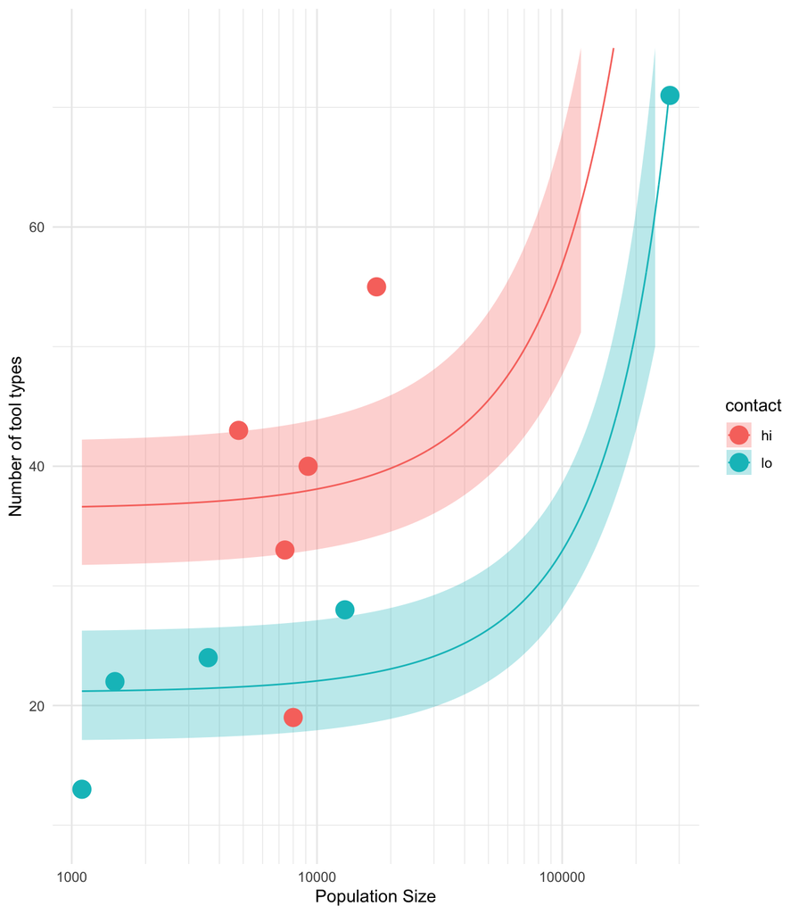

```r
tool_model = glm(tool_types ~ contact + population,
                 data = tools, family = poisson)
anova(tool_model, test = "Chisq")
## Analysis of Deviance Table
##
## Model: poisson, link: log
##
## Response: tool_types
##
## Terms added sequentially (first to last)
##
##
##            Df Deviance Resid. Df Resid. Dev  Pr(>Chi)
## NULL                           9     78.650
## contact     1    2.947         8     75.703   0.08605 .
## population  1   51.886         7     23.817 5.881e-13 ***
## ---
## Signif. codes:  0 '***' 0.001 '**' 0.01 '*' 0.05 '.' 0.1 ' ' 1
```

# Why not just transform y?

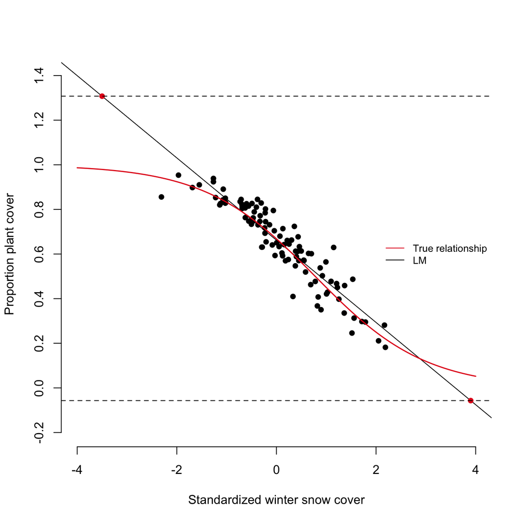

# Why not just transform y?

```r
    c(true_mean = mean(y),
      trans_y = exp(mean(log(y))),
      glm = exp(log(mean(y))))
## true_mean   trans_y       glm
## 0.6454693 0.6139760 0.6454693
```

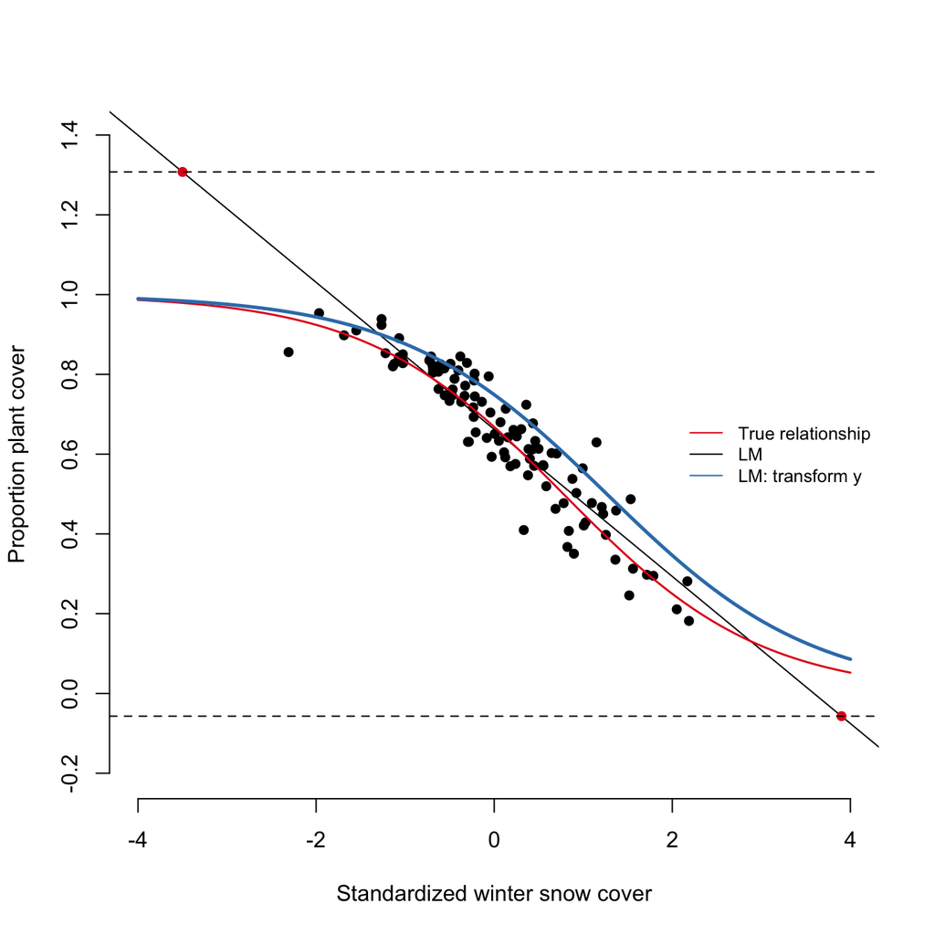

# Last example

- Hypothesis tests give us false confidence about $H_A$!

# Last example

One in 100,000 people have a condition, sigmocogititis, that causes you to think too much about statistics.

- $H_0$: I do not have the disease
- $H_A$: I have it!

We have a test with a type 1 error rate ($\alpha$) = 0.05, and a type 2 error rate ($\beta$) of 0.

# Last example

One in 100,000 people have a condition, sigmocogititis, that causes you to think too much about statistics.

- $H_0$: I do not have the disease
- $H_A$: I have it!

We have a test with a type 1 error rate ($\alpha$) = 0.05, and a type 2 error rate ($\beta$) of 0.

I take the test, p < 0.05, and so I begin treating my condition.

# Last example

One in 100,000 people have a condition, sigmocogititis, that causes you to think too much about statistics.

- $H_0$: I do not have the disease
- $H_A$: I have it!

We have a test with a type 1 error rate ($\alpha$) = 0.05, and a type 2 error rate ($\beta$) of 0.

I take the test, p < 0.05, and so I begin treating my condition.

**Problem**: The probability that I have the disease is only 0.0002!

If we test 100,000 people with unknown status, 5% (5000) will test positive, but only one will have the condition. We made the wrong decision in 4999/5000 of these cases!

# Last example

One in 100,000 people have a condition, sigmocogititis, that causes you to think too much about statistics.

- $H_0$: I do not have the disease
- $H_A$: I have it!

We have a test with a type 1 error rate ($\alpha$) = 0.05, and a type 2 error rate ($\beta$) of 0.

I take the test, p < 0.05, and so I begin treating my condition.

**Problem**: The probability that I have the disease is only 0.0002!

If we test 100,000 people with unknown status, 5% (5000) will test positive, but only one will have the condition. We made the wrong decision in 4999/5000 of these cases!

- In statistics, often called the **base rate fallacy**
- In science, we call this **the replication crisis**
- Considering only $\alpha$ and $H_0$ means we neglect to consider the plausibility of $H_A$